# R Notebook

```r
library(rpart)
library(rpart.plot)
library(tidyverse)

titanic_set <- read_csv('data/titanic_decision_tree_data.csv')
shuffle_index <- sample(1:nrow(titanic_set))

# shuffle the data so class order isn't in order - need this for training/testing split later on
titanic_set <- titanic_set[shuffle_index, ]
```

1.1 Question 1. Cleaning up the data is always the first step. Do the following:

Take only observations which have a survived flag (i.e. that aren’t missing) Turn your important variables into factors (sex, survived, pclass, embarkation) Create an age_status variable which groups individuals under (and including) 16 years of age into a category called “child” category and those over 16 into a category called “adult”. Drop the NA Drop any variables you don’t need (X1, passenger_id, name, ticket, far, cabin) If you need help doing this, the code is below, but please try it yourself first so you can learn!

```r
titanic_clean <- titanic_set %>%
  filter(survived %in% c(0,1)) %>%
# Convert to factor level
    mutate(sex = as.factor(sex),
           age_status = as.factor(if_else(age <= 16, "child", "adult")),
         class = factor(pclass, levels = c(3,2,1), labels = c("Lower", "Middle", "Upper")),
           survived_flag = factor(survived, levels = c(0,1), labels = c("No", "Yes")),
           port_embarkation = as.factor(embarked)) %>%
  select(sex, age_status, class, port_embarkation, sib_sp, parch, survived_flag) %>%
  na.omit()
```

1.2 Question 2. Have a look at your data and create some plots to ensure you know what you’re working with before you begin. Write a summary of what you have found in your plots. Which variables do you think might be useful to predict whether or not people are going to die? Knowing this before you start is the best way to have a sanity check that your model is doing a good job.

To summarise the following plots we can see that the greatest percentage of those who did not survive were from the Lower Class of the ship and a greater proportion of males than females did not survive. Additionally the breakdown of passengers by port shows that a high majority of all passengers embarked at Southampton (S) and the majority of those that travelled were adults.

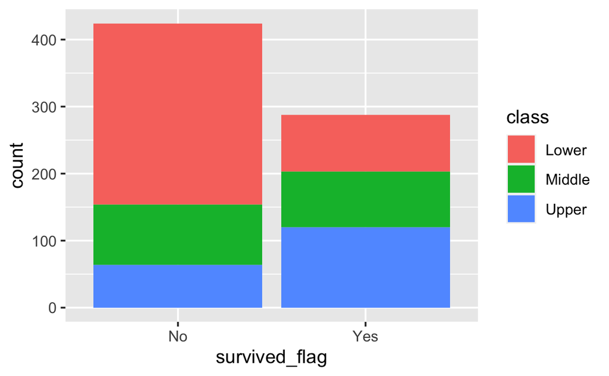

```r
titanic_clean %>%
  ggplot() +
  aes(x = survived_flag, fill = class) +
  geom_bar()
```

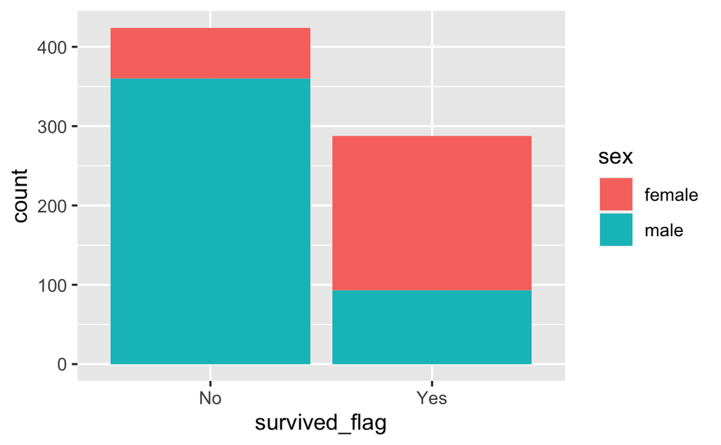

```r
titanic_clean %>%
  ggplot() +
  aes(x = survived_flag, fill = sex) +
  geom_bar()
```

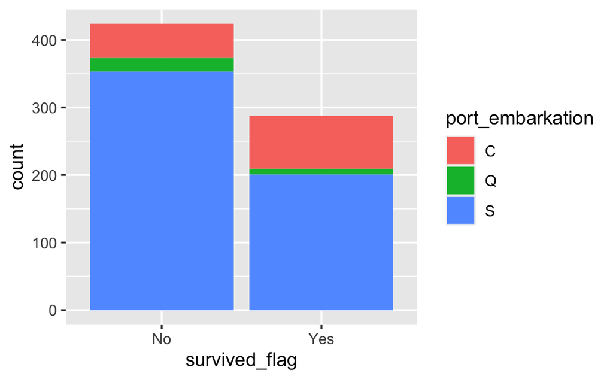

```r
titanic_clean %>%
  ggplot() +
  aes(x = survived_flag, fill = port_embarkation) +
  geom_bar()
```

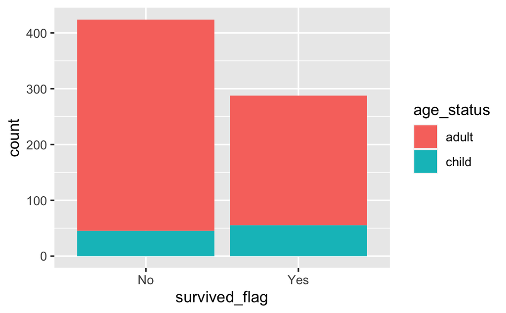

```r
titanic_clean %>%
  ggplot() +
  aes(x = survived_flag, fill = age_status) +
  geom_bar()
```

1.3 Question 3. Now you can start to build your model. Create your testing and training set using an appropriate split. Check you have balanced sets. Write down why you chose the split you did and produce output tables to show whether or not it is balanced. [Extra - if you want to force balanced testing and training sets, have a look at the stratified() function in package splitstackshape (you can specify multiple variables to stratify on by passing a vector of variable names to the group argument, and get back testing and training sets with argument bothSets = TRUE)]

```r
glimpse(titanic_clean)
```

```
Rows: 712
Columns: 7
$ sex              <fct> male, male, male, female, male, f…
$ age_status       <fct> adult, adult, adult, adult, child…
$ class            <fct> Middle, Lower, Lower, Upper, Midd…
$ port_embarkation <fct> S, C, S, C, S, S, S, S, S, S, S, …
$ sib_sp           <dbl> 0, 0, 0, 0, 1, 0, 1, 1, 0, 0, 0, …
$ parch            <dbl> 0, 0, 0, 0, 1, 0, 5, 1, 0, 0, 0, …
$ survived_flag    <fct> Yes, No, No, Yes, Yes, Yes, No, N…
```

```r
n_data <- nrow(thrones)
```

[output not shown]

[output not shown]

```r
titanic_test %>%
  janitor::tabyl(survived_flag)
```

```
 survived_flag  n   percent
            No 85 0.5821918
           Yes 61 0.4178082
```

```r
titanic_train %>%
  janitor::tabyl(survived_flag)
```

```
 survived_flag   n   percent
            No 339 0.5989399
           Yes 227 0.4010601
```

[figure not shown]

1.4 Question 4. Create your decision tree to try and predict survival probability using an appropriate method, and create a decision tree plot.

1.5 Question 5. Write down what this tells you, in detail. What variables are important? What does each node tell you? Who has the highest chance of surviving? Who has the lowest? Provide as much detail as you can.

1.6 Question 6. Test and add your predictions to your data. Create a confusion matrix. Write down in detail what this tells you for this specific dataset.